# Risk Factor Analysis

## Outcome Variable

**Outcome Variable:** stunted

## Predictor Variables

**Intervention Variable:** meducyrs

**Adjustment Set:**

- arm
- W_mage
- feducyrs
- hhwealth_quart
- W_mhtcm
- W_mwtkg
- W_mbmi
- W_gagebrth
- W_birthwt
- W_birthlen
- single
- W_nrooms
- impsan
- delta_W_mage
- delta_feducyrs
- delta_hhwealth_quart
- delta_W_mhtcm
- delta_W_mwtkg
- delta_W_mbmi
- delta_W_gagebrth
- delta_W_birthwt
- delta_W_birthlen
- delta_single
- delta_W_nrooms
- delta_impsan

## Stratifying Variables

The analysis was stratified on these variable(s):

- agecat
- studyid
- country

## Data Summary

| agecat | studyid | country | meducyrs | stunted | n_cell | n |
| --- | --- | --- | --- | --- | --- | --- |
| Birth | CMC-V-BCS-2002 | INDIA | High | 0 | 43 | 92 |
| Birth | CMC-V-BCS-2002 | INDIA | High | 1 | 8 | 92 |
| Birth | CMC-V-BCS-2002 | INDIA | Low | 0 | 14 | 92 |
| Birth | CMC-V-BCS-2002 | INDIA | Low | 1 | 2 | 92 |
| Birth | CMC-V-BCS-2002 | INDIA | Medium | 0 | 18 | 92 |
| Birth | CMC-V-BCS-2002 | INDIA | Medium | 1 | 7 | 92 |
| Birth | COHORTS | GUATEMALA | High | 0 | 168 | 842 |
| Birth | COHORTS | GUATEMALA | High | 1 | 10 | 842 |
| Birth | COHORTS | GUATEMALA | Low | 0 | 361 | 842 |
| Birth | COHORTS | GUATEMALA | Low | 1 | 30 | 842 |
| Birth | COHORTS | GUATEMALA | Medium | 0 | 264 | 842 |
| Birth | COHORTS | GUATEMALA | Medium | 1 | 9 | 842 |
| Birth | COHORTS | INDIA | High | 0 | 626 | 5216 |
| Birth | COHORTS | INDIA | High | 1 | 52 | 5216 |
| Birth | COHORTS | INDIA | Low | 0 | 1505 | 5216 |
| Birth | COHORTS | INDIA | Low | 1 | 251 | 5216 |
| Birth | COHORTS | INDIA | Medium | 0 | 2468 | 5216 |
| Birth | COHORTS | INDIA | Medium | 1 | 314 | 5216 |
| Birth | COHORTS | PHILIPPINES | High | 0 | 1114 | 3050 |
| Birth | COHORTS | PHILIPPINES | High | 1 | 55 | 3050 |
| Birth | COHORTS | PHILIPPINES | Low | 0 | 830 | 3050 |
| Birth | COHORTS | PHILIPPINES | Low | 1 | 70 | 3050 |
| Birth | COHORTS | PHILIPPINES | Medium | 0 | 919 | 3050 |
| Birth | COHORTS | PHILIPPINES | Medium | 1 | 62 | 3050 |
| Birth | EE | PAKISTAN | High | 0 | 4 | 239 |
| Birth | EE | PAKISTAN | High | 1 | 3 | 239 |
| Birth | EE | PAKISTAN | Low | 0 | 122 | 239 |
| Birth | EE | PAKISTAN | Low | 1 | 93 | 239 |
| Birth | EE | PAKISTAN | Medium | 0 | 14 | 239 |
| Birth | EE | PAKISTAN | Medium | 1 | 3 | 239 |

[output cut: 396 more lines]

The following strata were considered:

- agecat: 24 months, studyid: CMC-V-BCS-2002, country: INDIA
- agecat: 24 months, studyid: COHORTS, country: GUATEMALA
- agecat: 24 months, studyid: COHORTS, country: INDIA
- agecat: 24 months, studyid: COHORTS, country: PHILIPPINES
- agecat: 24 months, studyid: EE, country: PAKISTAN
- agecat: 24 months, studyid: GMS-Nepal, country: NEPAL
- agecat: 24 months, studyid: IRC, country: INDIA
- agecat: 24 months, studyid: JiVitA-3, country: BANGLADESH
- agecat: 24 months, studyid: JiVitA-4, country: BANGLADESH
- agecat: 24 months, studyid: LCNI-5, country: MALAWI
- agecat: 24 months, studyid: MAL-ED, country: BANGLADESH
- agecat: 24 months, studyid: MAL-ED, country: BRAZIL
- agecat: 24 months, studyid: MAL-ED, country: INDIA
- agecat: 24 months, studyid: MAL-ED, country: NEPAL
- agecat: 24 months, studyid: MAL-ED, country: PERU
- agecat: 24 months, studyid: MAL-ED, country: SOUTH AFRICA
- agecat: 24 months, studyid: MAL-ED, country: TANZANIA, UNITED REPUBLIC OF
- agecat: 24 months, studyid: NIH-Birth, country: BANGLADESH
- agecat: 24 months, studyid: NIH-Crypto, country: BANGLADESH
- agecat: 24 months, studyid: PROBIT, country: BELARUS
- agecat: 24 months, studyid: PROVIDE, country: BANGLADESH
- agecat: 24 months, studyid: TanzaniaChild2, country: TANZANIA, UNITED REPUBLIC OF
- agecat: 24 months, studyid: ZVITAMBO, country: ZIMBABWE
- agecat: 6 months, studyid: CMC-V-BCS-2002, country: INDIA
- agecat: 6 months, studyid: COHORTS, country: GUATEMALA
- agecat: 6 months, studyid: COHORTS, country: INDIA
- agecat: 6 months, studyid: COHORTS, country: PHILIPPINES
- agecat: 6 months, studyid: EE, country: PAKISTAN
- agecat: 6 months, studyid: GMS-Nepal, country: NEPAL
- agecat: 6 months, studyid: Guatemala BSC, country: GUATEMALA
- agecat: 6 months, studyid: IRC, country: INDIA
- agecat: 6 months, studyid: JiVitA-3, country: BANGLADESH
- agecat: 6 months, studyid: JiVitA-4, country: BANGLADESH
- agecat: 6 months, studyid: LCNI-5, country: MALAWI
- agecat: 6 months, studyid: MAL-ED, country: BANGLADESH
- agecat: 6 months, studyid: MAL-ED, country: BRAZIL
- agecat: 6 months, studyid: MAL-ED, country: INDIA
- agecat: 6 months, studyid: MAL-ED, country: NEPAL
- agecat: 6 months, studyid: MAL-ED, country: PERU
- agecat: 6 months, studyid: MAL-ED, country: SOUTH AFRICA
- agecat: 6 months, studyid: MAL-ED, country: TANZANIA, UNITED REPUBLIC OF
- agecat: 6 months, studyid: NIH-Birth, country: BANGLADESH
- agecat: 6 months, studyid: NIH-Crypto, country: BANGLADESH
- agecat: 6 months, studyid: PROBIT, country: BELARUS
- agecat: 6 months, studyid: PROVIDE, country: BANGLADESH
- agecat: 6 months, studyid: SAS-CompFeed, country: INDIA
- agecat: 6 months, studyid: SAS-FoodSuppl, country: INDIA
- agecat: 6 months, studyid: TanzaniaChild2, country: TANZANIA, UNITED REPUBLIC OF
- agecat: 6 months, studyid: ZVITAMBO, country: ZIMBABWE
- agecat: Birth, studyid: CMC-V-BCS-2002, country: INDIA
- agecat: Birth, studyid: COHORTS, country: GUATEMALA
- agecat: Birth, studyid: COHORTS, country: INDIA
- agecat: Birth, studyid: COHORTS, country: PHILIPPINES
- agecat: Birth, studyid: EE, country: PAKISTAN
- agecat: Birth, studyid: GMS-Nepal, country: NEPAL
- agecat: Birth, studyid: IRC, country: INDIA
- agecat: Birth, studyid: JiVitA-3, country: BANGLADESH
- agecat: Birth, studyid: JiVitA-4, country: BANGLADESH
- agecat: Birth, studyid: MAL-ED, country: BANGLADESH
- agecat: Birth, studyid: MAL-ED, country: BRAZIL
- agecat: Birth, studyid: MAL-ED, country: INDIA
- agecat: Birth, studyid: MAL-ED, country: NEPAL
- agecat: Birth, studyid: MAL-ED, country: PERU
- agecat: Birth, studyid: MAL-ED, country: SOUTH AFRICA
- agecat: Birth, studyid: MAL-ED, country: TANZANIA, UNITED REPUBLIC OF
- agecat: Birth, studyid: NIH-Birth, country: BANGLADESH
- agecat: Birth, studyid: NIH-Crypto, country: BANGLADESH
- agecat: Birth, studyid: PROBIT, country: BELARUS
- agecat: Birth, studyid: PROVIDE, country: BANGLADESH
- agecat: Birth, studyid: SAS-CompFeed, country: INDIA
- agecat: Birth, studyid: ZVITAMBO, country: ZIMBABWE

### Dropped Strata

Some strata were dropped due to rare outcomes:

- agecat: Birth, studyid: CMC-V-BCS-2002, country: INDIA
- agecat: Birth, studyid: EE, country: PAKISTAN
- agecat: Birth, studyid: MAL-ED, country: BRAZIL
- agecat: Birth, studyid: MAL-ED, country: INDIA
- agecat: Birth, studyid: MAL-ED, country: NEPAL
- agecat: Birth, studyid: MAL-ED, country: SOUTH AFRICA
- agecat: Birth, studyid: MAL-ED, country: TANZANIA, UNITED REPUBLIC OF
- agecat: Birth, studyid: PROBIT, country: BELARUS
- agecat: 6 months, studyid: EE, country: PAKISTAN
- agecat: 6 months, studyid: MAL-ED, country: BRAZIL
- agecat: 6 months, studyid: MAL-ED, country: NEPAL
- agecat: 6 months, studyid: MAL-ED, country: TANZANIA, UNITED REPUBLIC OF
- agecat: 24 months, studyid: EE, country: PAKISTAN
- agecat: 24 months, studyid: MAL-ED, country: BRAZIL
- agecat: 24 months, studyid: MAL-ED, country: TANZANIA, UNITED REPUBLIC OF
- agecat: 24 months, studyid: TanzaniaChild2, country: TANZANIA, UNITED REPUBLIC OF

## Methods Detail

We’re interested in the causal parameters $E[Y_a]$ for all values of $a \in \mathcal{A}$. These parameters represent the mean outcome if, possibly contrary to fact, we intervened to set all units to have $A=a$. Under the randomization and positivity assumptions, these are identified by the statistical parameters $\psi_a=E_W[E_{Y|A,W}(Y|A=a,W)]$. In addition, we’re interested in the mean of $Y$, $E[Y]$ under no intervention (the observed mean). We will estimate these parameters by using SuperLearner to fit the relevant likelihood factors – $E_{Y|A,W}(Y|A=a,W)$ and $p(A=a|W)$, and then updating our likelihood fit using a joint TMLE.

For unadjusted analyses ($W=\{\}$), initial likelihoods were estimated using Lrnr_glm to estimate the simple $E(Y|A)$ and Lrnr_mean to estimate $p(A)$. For adjusted analyses, a small library containing Lrnr_glmnet, Lrnr_xgboost, and Lrnr_mean was used.

Having estimated these parameters, we will then use the delta method to estimate relative risks and attributable risks relative to a prespecified baseline level of $A$.

# Results Detail

## Results Plots

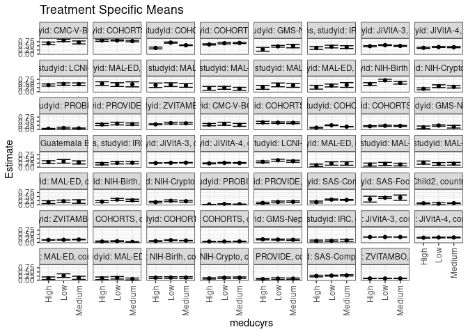

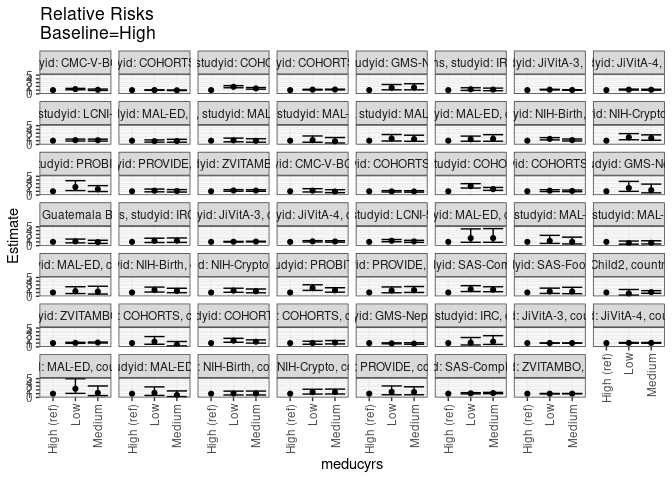

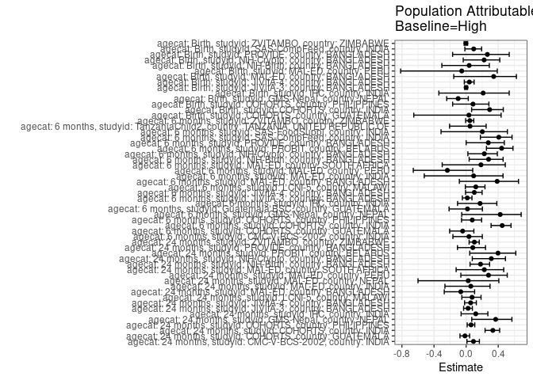

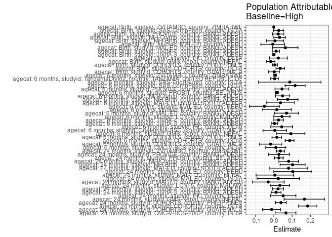

## Results Table

### Parameter: TSM

| agecat | studyid | country | intervention_level | baseline_level | estimate | ci_lower | ci_upper |
| --- | --- | --- | --- | --- | --- | --- | --- |
| Birth | COHORTS | GUATEMALA | High | NA | 0.0561798 | 0.0223319 | 0.0900276 |
| Birth | COHORTS | GUATEMALA | Low | NA | 0.0767263 | 0.0503293 | 0.1031234 |
| Birth | COHORTS | GUATEMALA | Medium | NA | 0.0329670 | 0.0117744 | 0.0541597 |
| Birth | COHORTS | INDIA | High | NA | 0.0836501 | 0.0598534 | 0.1074468 |
| Birth | COHORTS | INDIA | Low | NA | 0.1389104 | 0.1214419 | 0.1563789 |
| Birth | COHORTS | INDIA | Medium | NA | 0.1135654 | 0.1007929 | 0.1263379 |
| Birth | COHORTS | PHILIPPINES | High | NA | 0.0560803 | 0.0405645 | 0.0715961 |
| Birth | COHORTS | PHILIPPINES | Low | NA | 0.0566559 | 0.0409054 | 0.0724064 |
| Birth | COHORTS | PHILIPPINES | Medium | NA | 0.0636225 | 0.0466162 | 0.0806288 |
| Birth | GMS-Nepal | NEPAL | High | NA | 0.1935244 | 0.1575818 | 0.2294671 |
| Birth | GMS-Nepal | NEPAL | Low | NA | 0.1772999 | 0.1477370 | 0.2068629 |
| Birth | GMS-Nepal | NEPAL | Medium | NA | 0.1671586 | 0.1276048 | 0.2067125 |
| Birth | IRC | INDIA | High | NA | 0.0913836 | 0.0356367 | 0.1471305 |
| Birth | IRC | INDIA | Low | NA | 0.1014889 | 0.0485180 | 0.1544597 |
| Birth | IRC | INDIA | Medium | NA | 0.1256400 | 0.0664508 | 0.1848291 |
| Birth | JiVitA-3 | BANGLADESH | High | NA | 0.3291668 | 0.3200120 | 0.3383215 |
| Birth | JiVitA-3 | BANGLADESH | Low | NA | 0.3316111 | 0.3228018 | 0.3404204 |
| Birth | JiVitA-3 | BANGLADESH | Medium | NA | 0.3304075 | 0.3215101 | 0.3393049 |
| Birth | JiVitA-4 | BANGLADESH | High | NA | 0.2912381 | 0.2639751 | 0.3185011 |
| Birth | JiVitA-4 | BANGLADESH | Low | NA | 0.3068633 | 0.2834418 | 0.3302848 |
| Birth | JiVitA-4 | BANGLADESH | Medium | NA | 0.3062432 | 0.2816692 | 0.3308171 |
| Birth | MAL-ED | BANGLADESH | High | NA | 0.1194030 | 0.0415507 | 0.1972552 |
| Birth | MAL-ED | BANGLADESH | Low | NA | 0.2769231 | 0.1678475 | 0.3859987 |
| Birth | MAL-ED | BANGLADESH | Medium | NA | 0.1454545 | 0.0520297 | 0.2388794 |
| Birth | MAL-ED | PERU | High | NA | 0.1176471 | 0.0409040 | 0.1943902 |
| Birth | MAL-ED | PERU | Low | NA | 0.1428571 | 0.0678643 | 0.2178500 |
| Birth | MAL-ED | PERU | Medium | NA | 0.0740741 | 0.0169182 | 0.1312299 |
| Birth | NIH-Birth | BANGLADESH | High | NA | 0.1535170 | 0.0994071 | 0.2076269 |
| Birth | NIH-Birth | BANGLADESH | Low | NA | 0.1608681 | 0.1123214 | 0.2094148 |
| Birth | NIH-Birth | BANGLADESH | Medium | NA | 0.1610352 | 0.1098736 | 0.2121969 |

[output cut: 135 more lines]

### Parameter: E(Y)

| agecat | studyid | country | intervention_level | baseline_level | estimate | ci_lower | ci_upper |
| --- | --- | --- | --- | --- | --- | --- | --- |
| Birth | COHORTS | GUATEMALA | NA | NA | 0.0581948 | 0.0423724 | 0.0740172 |
| Birth | COHORTS | INDIA | NA | NA | 0.1182899 | 0.1095248 | 0.1270550 |
| Birth | COHORTS | PHILIPPINES | NA | NA | 0.0613115 | 0.0527962 | 0.0698268 |
| Birth | GMS-Nepal | NEPAL | NA | NA | 0.1760462 | 0.1476696 | 0.2044227 |
| Birth | IRC | INDIA | NA | NA | 0.1159794 | 0.0840777 | 0.1478811 |
| Birth | JiVitA-3 | BANGLADESH | NA | NA | 0.3290676 | 0.3216916 | 0.3364437 |
| Birth | JiVitA-4 | BANGLADESH | NA | NA | 0.3035144 | 0.2834906 | 0.3235382 |
| Birth | MAL-ED | BANGLADESH | NA | NA | 0.1818182 | 0.1263894 | 0.2372469 |
| Birth | MAL-ED | PERU | NA | NA | 0.1115880 | 0.0710726 | 0.1521034 |
| Birth | NIH-Birth | BANGLADESH | NA | NA | 0.1595395 | 0.1304091 | 0.1886699 |
| Birth | NIH-Crypto | BANGLADESH | NA | NA | 0.1379781 | 0.1129774 | 0.1629789 |
| Birth | PROVIDE | BANGLADESH | NA | NA | 0.0890538 | 0.0649864 | 0.1131212 |
| Birth | SAS-CompFeed | INDIA | NA | NA | 0.2787540 | 0.2475949 | 0.3099131 |
| Birth | ZVITAMBO | ZIMBABWE | NA | NA | 0.1035005 | 0.0984282 | 0.1085729 |
| 6 months | CMC-V-BCS-2002 | INDIA | NA | NA | 0.3008130 | 0.2539566 | 0.3476694 |
| 6 months | COHORTS | GUATEMALA | NA | NA | 0.4075630 | 0.3763327 | 0.4387933 |
| 6 months | COHORTS | INDIA | NA | NA | 0.1915758 | 0.1810911 | 0.2020606 |
| 6 months | COHORTS | PHILIPPINES | NA | NA | 0.2112260 | 0.1958496 | 0.2266024 |
| 6 months | GMS-Nepal | NEPAL | NA | NA | 0.2174688 | 0.1833021 | 0.2516355 |
| 6 months | Guatemala BSC | GUATEMALA | NA | NA | 0.3104693 | 0.2558835 | 0.3650551 |
| 6 months | IRC | INDIA | NA | NA | 0.2457002 | 0.2038248 | 0.2875757 |
| 6 months | JiVitA-3 | BANGLADESH | NA | NA | 0.2514589 | 0.2433251 | 0.2595926 |
| 6 months | JiVitA-4 | BANGLADESH | NA | NA | 0.2525944 | 0.2385189 | 0.2666699 |
| 6 months | LCNI-5 | MALAWI | NA | NA | 0.3628536 | 0.3297820 | 0.3959252 |
| 6 months | MAL-ED | BANGLADESH | NA | NA | 0.1785714 | 0.1248161 | 0.2323268 |
| 6 months | MAL-ED | INDIA | NA | NA | 0.1682692 | 0.1173060 | 0.2192324 |
| 6 months | MAL-ED | PERU | NA | NA | 0.2205882 | 0.1712211 | 0.2699554 |
| 6 months | MAL-ED | SOUTH AFRICA | NA | NA | 0.1968504 | 0.1478551 | 0.2458457 |
| 6 months | NIH-Birth | BANGLADESH | NA | NA | 0.2681564 | 0.2306532 | 0.3056597 |
| 6 months | NIH-Crypto | BANGLADESH | NA | NA | 0.2097902 | 0.1799252 | 0.2396552 |
| 6 months | PROBIT | BELARUS | NA | NA | 0.0393401 | 0.0293640 | 0.0493162 |
| 6 months | PROVIDE | BANGLADESH | NA | NA | 0.1589404 | 0.1297581 | 0.1881227 |
| 6 months | SAS-CompFeed | INDIA | NA | NA | 0.2844311 | 0.2666491 | 0.3022132 |
| 6 months | SAS-FoodSuppl | INDIA | NA | NA | 0.4289474 | 0.3791199 | 0.4787748 |
| 6 months | TanzaniaChild2 | TANZANIA, UNITED REPUBLIC OF | NA | NA | 0.0964869 | 0.0836111 | 0.1093627 |
| 6 months | ZVITAMBO | ZIMBABWE | NA | NA | 0.1631427 | 0.1553579 | 0.1709275 |
| 24 months | CMC-V-BCS-2002 | INDIA | NA | NA | 0.7169811 | 0.6710815 | 0.7628807 |
| 24 months | COHORTS | GUATEMALA | NA | NA | 0.8107852 | 0.7871616 | 0.8344089 |
| 24 months | COHORTS | INDIA | NA | NA | 0.5531205 | 0.5380793 | 0.5681618 |
| 24 months | COHORTS | PHILIPPINES | NA | NA | 0.6229039 | 0.6036892 | 0.6421186 |
| 24 months | GMS-Nepal | NEPAL | NA | NA | 0.4515464 | 0.4072114 | 0.4958814 |
| 24 months | IRC | INDIA | NA | NA | 0.4205379 | 0.3726382 | 0.4684376 |
| 24 months | JiVitA-3 | BANGLADESH | NA | NA | 0.4911263 | 0.4780235 | 0.5042291 |
| 24 months | JiVitA-4 | BANGLADESH | NA | NA | 0.4013921 | 0.3844229 | 0.4183613 |
| 24 months | LCNI-5 | MALAWI | NA | NA | 0.4405594 | 0.3998393 | 0.4812796 |
| 24 months | MAL-ED | BANGLADESH | NA | NA | 0.4619883 | 0.3870446 | 0.5369320 |
| 24 months | MAL-ED | INDIA | NA | NA | 0.4170854 | 0.3484054 | 0.4857655 |
| 24 months | MAL-ED | NEPAL | NA | NA | 0.2112676 | 0.1563184 | 0.2662168 |
| 24 months | MAL-ED | PERU | NA | NA | 0.3700000 | 0.3029201 | 0.4370799 |
| 24 months | MAL-ED | SOUTH AFRICA | NA | NA | 0.3529412 | 0.2921001 | 0.4137823 |
| 24 months | NIH-Birth | BANGLADESH | NA | NA | 0.5687646 | 0.5218455 | 0.6156837 |
| 24 months | NIH-Crypto | BANGLADESH | NA | NA | 0.2568093 | 0.2190047 | 0.2946140 |
| 24 months | PROBIT | BELARUS | NA | NA | 0.0681537 | 0.0420376 | 0.0942697 |
| 24 months | PROVIDE | BANGLADESH | NA | NA | 0.3287197 | 0.2903909 | 0.3670485 |
| 24 months | ZVITAMBO | ZIMBABWE | NA | NA | 0.3471629 | 0.3241082 | 0.3702176 |

### Parameter: RR

| agecat | studyid | country | intervention_level | baseline_level | estimate | ci_lower | ci_upper |
| --- | --- | --- | --- | --- | --- | --- | --- |
| Birth | COHORTS | GUATEMALA | High | High | 1.0000000 | 1.0000000 | 1.000000 |
| Birth | COHORTS | GUATEMALA | Low | High | 1.3657289 | 0.6824179 | 2.733245 |
| Birth | COHORTS | GUATEMALA | Medium | High | 0.5868132 | 0.2431453 | 1.416230 |
| Birth | COHORTS | INDIA | High | High | 1.0000000 | 1.0000000 | 1.000000 |
| Birth | COHORTS | INDIA | Low | High | 1.6606118 | 1.2167368 | 2.266416 |
| Birth | COHORTS | INDIA | Medium | High | 1.3576233 | 0.9999565 | 1.843221 |
| Birth | COHORTS | PHILIPPINES | High | High | 1.0000000 | 1.0000000 | 1.000000 |
| Birth | COHORTS | PHILIPPINES | Low | High | 1.0102634 | 0.6855826 | 1.488708 |
| Birth | COHORTS | PHILIPPINES | Medium | High | 1.1344892 | 0.7752746 | 1.660142 |
| Birth | GMS-Nepal | NEPAL | High | High | 1.0000000 | 1.0000000 | 1.000000 |
| Birth | GMS-Nepal | NEPAL | Low | High | 0.9161632 | 0.7942965 | 1.056728 |
| Birth | GMS-Nepal | NEPAL | Medium | High | 0.8637599 | 0.6939535 | 1.075117 |
| Birth | IRC | INDIA | High | High | 1.0000000 | 1.0000000 | 1.000000 |
| Birth | IRC | INDIA | Low | High | 1.1105813 | 0.4956531 | 2.488415 |
| Birth | IRC | INDIA | Medium | High | 1.3748638 | 0.6355140 | 2.974365 |
| Birth | JiVitA-3 | BANGLADESH | High | High | 1.0000000 | 1.0000000 | 1.000000 |
| Birth | JiVitA-3 | BANGLADESH | Low | High | 1.0074259 | 0.9816815 | 1.033845 |
| Birth | JiVitA-3 | BANGLADESH | Medium | High | 1.0037693 | 0.9795401 | 1.028598 |
| Birth | JiVitA-4 | BANGLADESH | High | High | 1.0000000 | 1.0000000 | 1.000000 |
| Birth | JiVitA-4 | BANGLADESH | Low | High | 1.0536511 | 0.9645071 | 1.151034 |
| Birth | JiVitA-4 | BANGLADESH | Medium | High | 1.0515216 | 0.9582091 | 1.153921 |
| Birth | MAL-ED | BANGLADESH | High | High | 1.0000000 | 1.0000000 | 1.000000 |
| Birth | MAL-ED | BANGLADESH | Low | High | 2.3192308 | 1.0827284 | 4.967849 |
| Birth | MAL-ED | BANGLADESH | Medium | High | 1.2181818 | 0.4877850 | 3.042256 |
| Birth | MAL-ED | PERU | High | High | 1.0000000 | 1.0000000 | 1.000000 |
| Birth | MAL-ED | PERU | Low | High | 1.2142857 | 0.5256316 | 2.805177 |
| Birth | MAL-ED | PERU | Medium | High | 0.6296296 | 0.2292335 | 1.729387 |
| Birth | NIH-Birth | BANGLADESH | High | High | 1.0000000 | 1.0000000 | 1.000000 |
| Birth | NIH-Birth | BANGLADESH | Low | High | 1.0478846 | 0.6591193 | 1.665954 |
| Birth | NIH-Birth | BANGLADESH | Medium | High | 1.0489731 | 0.6526206 | 1.686040 |

[output cut: 135 more lines]

### Parameter: PAR

| agecat | studyid | country | intervention_level | baseline_level | estimate | ci_lower | ci_upper |
| --- | --- | --- | --- | --- | --- | --- | --- |
| Birth | COHORTS | GUATEMALA | High | NA | 0.0020150 | -0.0281782 | 0.0322082 |
| Birth | COHORTS | INDIA | High | NA | 0.0346397 | 0.0114320 | 0.0578475 |
| Birth | COHORTS | PHILIPPINES | High | NA | 0.0052312 | -0.0085326 | 0.0189950 |
| Birth | GMS-Nepal | NEPAL | High | NA | -0.0174782 | -0.0407955 | 0.0058390 |
| Birth | IRC | INDIA | High | NA | 0.0245958 | -0.0240445 | 0.0732361 |
| Birth | JiVitA-3 | BANGLADESH | High | NA | -0.0000991 | -0.0060159 | 0.0058177 |
| Birth | JiVitA-4 | BANGLADESH | High | NA | 0.0122763 | -0.0062744 | 0.0308270 |
| Birth | MAL-ED | BANGLADESH | High | NA | 0.0624152 | -0.0067958 | 0.1316262 |
| Birth | MAL-ED | PERU | High | NA | -0.0060591 | -0.0700384 | 0.0579202 |
| Birth | NIH-Birth | BANGLADESH | High | NA | 0.0060225 | -0.0404508 | 0.0524957 |
| Birth | NIH-Crypto | BANGLADESH | High | NA | 0.0309635 | -0.0005321 | 0.0624591 |
| Birth | PROVIDE | BANGLADESH | High | NA | 0.0235474 | -0.0072804 | 0.0543752 |
| Birth | SAS-CompFeed | INDIA | High | NA | 0.0263536 | -0.0012371 | 0.0539443 |
| Birth | ZVITAMBO | ZIMBABWE | High | NA | -0.0002979 | -0.0025291 | 0.0019333 |
| 6 months | CMC-V-BCS-2002 | INDIA | High | NA | 0.0107024 | -0.0440149 | 0.0654197 |
| 6 months | COHORTS | GUATEMALA | High | NA | -0.0177204 | -0.0789350 | 0.0434942 |
| 6 months | COHORTS | INDIA | High | NA | 0.0860375 | 0.0619284 | 0.1101466 |
| 6 months | COHORTS | PHILIPPINES | High | NA | 0.0161224 | -0.0102121 | 0.0424569 |
| 6 months | GMS-Nepal | NEPAL | High | NA | 0.0922927 | 0.0153697 | 0.1692158 |
| 6 months | Guatemala BSC | GUATEMALA | High | NA | 0.0051941 | -0.0587893 | 0.0691775 |
| 6 months | IRC | INDIA | High | NA | 0.0425956 | -0.0168832 | 0.1020743 |
| 6 months | JiVitA-3 | BANGLADESH | High | NA | 0.0036874 | -0.0113691 | 0.0187439 |
| 6 months | JiVitA-4 | BANGLADESH | High | NA | 0.0257332 | -0.0003628 | 0.0518291 |
| 6 months | LCNI-5 | MALAWI | High | NA | 0.0438786 | -0.0004004 | 0.0881576 |
| 6 months | MAL-ED | BANGLADESH | High | NA | 0.0689824 | 0.0041266 | 0.1338382 |
| 6 months | MAL-ED | INDIA | High | NA | 0.0157269 | -0.0633729 | 0.0948266 |
| 6 months | MAL-ED | PERU | High | NA | -0.0515124 | -0.1322210 | 0.0291962 |
| 6 months | MAL-ED | SOUTH AFRICA | High | NA | 0.0363445 | -0.0385966 | 0.1112856 |
| 6 months | NIH-Birth | BANGLADESH | High | NA | 0.0750179 | 0.0185225 | 0.1315132 |
| 6 months | NIH-Crypto | BANGLADESH | High | NA | 0.0475559 | 0.0088820 | 0.0862299 |
| 6 months | PROBIT | BELARUS | High | NA | 0.0174116 | 0.0088227 | 0.0260005 |
| 6 months | PROVIDE | BANGLADESH | High | NA | 0.0438584 | 0.0060842 | 0.0816326 |
| 6 months | SAS-CompFeed | INDIA | High | NA | 0.1157255 | 0.0609184 | 0.1705326 |
| 6 months | SAS-FoodSuppl | INDIA | High | NA | 0.0863776 | -0.0836869 | 0.2564421 |
| 6 months | TanzaniaChild2 | TANZANIA, UNITED REPUBLIC OF | High | NA | 0.0046900 | -0.0170934 | 0.0264734 |
| 6 months | ZVITAMBO | ZIMBABWE | High | NA | 0.0075246 | -0.0007749 | 0.0158241 |
| 24 months | CMC-V-BCS-2002 | INDIA | High | NA | 0.0655391 | 0.0106854 | 0.1203929 |
| 24 months | COHORTS | GUATEMALA | High | NA | -0.0120506 | -0.0606699 | 0.0365687 |
| 24 months | COHORTS | INDIA | High | NA | 0.1841960 | 0.1340914 | 0.2343005 |
| 24 months | COHORTS | PHILIPPINES | High | NA | 0.0384366 | 0.0090975 | 0.0677757 |
| 24 months | GMS-Nepal | NEPAL | High | NA | 0.1661920 | 0.0559065 | 0.2764775 |
| 24 months | IRC | INDIA | High | NA | 0.0504240 | -0.0192808 | 0.1201288 |
| 24 months | JiVitA-3 | BANGLADESH | High | NA | 0.0121733 | -0.0145351 | 0.0388816 |
| 24 months | JiVitA-4 | BANGLADESH | High | NA | 0.0227230 | -0.0067454 | 0.0521913 |
| 24 months | LCNI-5 | MALAWI | High | NA | 0.0325819 | -0.0198933 | 0.0850570 |
| 24 months | MAL-ED | BANGLADESH | High | NA | -0.0307877 | -0.1174378 | 0.0558625 |
| 24 months | MAL-ED | INDIA | High | NA | 0.0242424 | -0.0910817 | 0.1395665 |
| 24 months | MAL-ED | NEPAL | High | NA | 0.0055927 | -0.0965371 | 0.1077226 |
| 24 months | MAL-ED | PERU | High | NA | 0.1032299 | -0.0006478 | 0.2071077 |
| 24 months | MAL-ED | SOUTH AFRICA | High | NA | 0.0800981 | -0.0220762 | 0.1822724 |
| 24 months | NIH-Birth | BANGLADESH | High | NA | 0.1020766 | 0.0336004 | 0.1705527 |
| 24 months | NIH-Crypto | BANGLADESH | High | NA | 0.0805875 | 0.0272124 | 0.1339626 |
| 24 months | PROBIT | BELARUS | High | NA | 0.0270425 | 0.0033340 | 0.0507510 |
| 24 months | PROVIDE | BANGLADESH | High | NA | 0.0273782 | -0.0299739 | 0.0847303 |
| 24 months | ZVITAMBO | ZIMBABWE | High | NA | 0.0356451 | 0.0137371 | 0.0575532 |

### Parameter: PAF

| agecat | studyid | country | intervention_level | baseline_level | estimate | ci_lower | ci_upper |
| --- | --- | --- | --- | --- | --- | --- | --- |
| Birth | COHORTS | GUATEMALA | High | NA | 0.0346251 | -0.6522240 | 0.4359429 |
| Birth | COHORTS | INDIA | High | NA | 0.2928378 | 0.0686066 | 0.4630857 |
| Birth | COHORTS | PHILIPPINES | High | NA | 0.0853212 | -0.1681435 | 0.2837889 |
| Birth | GMS-Nepal | NEPAL | High | NA | -0.0992822 | -0.2418998 | 0.0269575 |
| Birth | IRC | INDIA | High | NA | 0.2120705 | -0.3397510 | 0.5366058 |
| Birth | JiVitA-3 | BANGLADESH | High | NA | -0.0003012 | -0.0184447 | 0.0175191 |
| Birth | JiVitA-4 | BANGLADESH | High | NA | 0.0404471 | -0.0227162 | 0.0997095 |
| Birth | MAL-ED | BANGLADESH | High | NA | 0.3432836 | -0.1542075 | 0.6263441 |
| Birth | MAL-ED | PERU | High | NA | -0.0542986 | -0.8156860 | 0.3878095 |
| Birth | NIH-Birth | BANGLADESH | High | NA | 0.0377490 | -0.3022792 | 0.2889950 |
| Birth | NIH-Crypto | BANGLADESH | High | NA | 0.2244085 | -0.0359510 | 0.4193333 |
| Birth | PROVIDE | BANGLADESH | High | NA | 0.2644179 | -0.1682389 | 0.5368404 |
| Birth | SAS-CompFeed | INDIA | High | NA | 0.0945408 | -0.0158599 | 0.1929435 |
| Birth | ZVITAMBO | ZIMBABWE | High | NA | -0.0028779 | -0.0246683 | 0.0184491 |
| 6 months | CMC-V-BCS-2002 | INDIA | High | NA | 0.0355782 | -0.1645264 | 0.2012981 |
| 6 months | COHORTS | GUATEMALA | High | NA | -0.0434788 | -0.2050932 | 0.0964615 |
| 6 months | COHORTS | INDIA | High | NA | 0.4491042 | 0.3108533 | 0.5596204 |
| 6 months | COHORTS | PHILIPPINES | High | NA | 0.0763278 | -0.0570253 | 0.1928572 |
| 6 months | GMS-Nepal | NEPAL | High | NA | 0.4243952 | -0.0547418 | 0.6858749 |
| 6 months | Guatemala BSC | GUATEMALA | High | NA | 0.0167299 | -0.2124821 | 0.2026108 |
| 6 months | IRC | INDIA | High | NA | 0.1733639 | -0.1066947 | 0.3825513 |
| 6 months | JiVitA-3 | BANGLADESH | High | NA | 0.0146639 | -0.0470633 | 0.0727522 |
| 6 months | JiVitA-4 | BANGLADESH | High | NA | 0.1018754 | -0.0072227 | 0.1991565 |
| 6 months | LCNI-5 | MALAWI | High | NA | 0.1209265 | -0.0098419 | 0.2347612 |
| 6 months | MAL-ED | BANGLADESH | High | NA | 0.3863014 | -0.0842433 | 0.6526370 |
| 6 months | MAL-ED | INDIA | High | NA | 0.0934625 | -0.5216944 | 0.4599374 |
| 6 months | MAL-ED | PERU | High | NA | -0.2335229 | -0.6583057 | 0.0824498 |
| 6 months | MAL-ED | SOUTH AFRICA | High | NA | 0.1846300 | -0.2982282 | 0.4878957 |
| 6 months | NIH-Birth | BANGLADESH | High | NA | 0.2797541 | 0.0379786 | 0.4607665 |
| 6 months | NIH-Crypto | BANGLADESH | High | NA | 0.2266833 | 0.0217016 | 0.3887154 |
| 6 months | PROBIT | BELARUS | High | NA | 0.4425919 | 0.2533943 | 0.5838450 |
| 6 months | PROVIDE | BANGLADESH | High | NA | 0.2759425 | 0.0001581 | 0.4756579 |
| 6 months | SAS-CompFeed | INDIA | High | NA | 0.4068665 | 0.1777352 | 0.5721483 |
| 6 months | SAS-FoodSuppl | INDIA | High | NA | 0.2013711 | -0.3123974 | 0.5140130 |
| 6 months | TanzaniaChild2 | TANZANIA, UNITED REPUBLIC OF | High | NA | 0.0486078 | -0.2061016 | 0.2495266 |
| 6 months | ZVITAMBO | ZIMBABWE | High | NA | 0.0461230 | -0.0060600 | 0.0955993 |
| 24 months | CMC-V-BCS-2002 | INDIA | High | NA | 0.0914099 | 0.0107165 | 0.1655213 |
| 24 months | COHORTS | GUATEMALA | High | NA | -0.0148629 | -0.0766280 | 0.0433588 |
| 24 months | COHORTS | INDIA | High | NA | 0.3330124 | 0.2359975 | 0.4177080 |
| 24 months | COHORTS | PHILIPPINES | High | NA | 0.0617055 | 0.0133505 | 0.1076907 |
| 24 months | GMS-Nepal | NEPAL | High | NA | 0.3680507 | 0.0702374 | 0.5704711 |
| 24 months | IRC | INDIA | High | NA | 0.1199036 | -0.0624076 | 0.2709298 |
| 24 months | JiVitA-3 | BANGLADESH | High | NA | 0.0247864 | -0.0311745 | 0.0777104 |
| 24 months | JiVitA-4 | BANGLADESH | High | NA | 0.0566104 | -0.0195103 | 0.1270475 |
| 24 months | LCNI-5 | MALAWI | High | NA | 0.0739556 | -0.0532626 | 0.1858078 |
| 24 months | MAL-ED | BANGLADESH | High | NA | -0.0666417 | -0.2724019 | 0.1058450 |
| 24 months | MAL-ED | INDIA | High | NA | 0.0581234 | -0.2638886 | 0.2980936 |
| 24 months | MAL-ED | NEPAL | High | NA | 0.0264722 | -0.5995352 | 0.4074802 |
| 24 months | MAL-ED | PERU | High | NA | 0.2789998 | -0.0658520 | 0.5122764 |
| 24 months | MAL-ED | SOUTH AFRICA | High | NA | 0.2269447 | -0.1245558 | 0.4685772 |
| 24 months | NIH-Birth | BANGLADESH | High | NA | 0.1794707 | 0.0484796 | 0.2924288 |
| 24 months | NIH-Crypto | BANGLADESH | High | NA | 0.3138028 | 0.0767245 | 0.4900042 |
| 24 months | PROBIT | BELARUS | High | NA | 0.3967865 | 0.0449243 | 0.6190182 |
| 24 months | PROVIDE | BANGLADESH | High | NA | 0.0832873 | -0.1079684 | 0.2415288 |
| 24 months | ZVITAMBO | ZIMBABWE | High | NA | 0.1026755 | 0.0374749 | 0.1634595 |